# Assignment 4

## Try to submit as an HTML file

Print your Emory ID below

```python
# Write down your answer here:
2508406
```

Import the numpy, matplotlib, and pandas packages

```python
# Write down your answer here:
import numpy as np
import matplotlib.pyplot as plt
import pandas as pd
```

(a) Create a sequence

- Create a value $n = 42$
- Create a list with the values $0,1,\ldots, n$
- Count the length of the list

```python
# Write your own code
n = 42
mylist = py.arange(0,43,1).tolist()
len(mylist)
```

```
43
```

(b) Counting True/False statements in a list

- Create list_age = [58, 23, 63, 18, 76, 35, 48, 68]
- Create an empty list "list_eligible_retire"
- Use a for-loop without numbering
  - Determine whether the age is $\ge 65$
  - Store the True/False result in "list_eligible_retire"
- Use "np.sum()" to count how many workers are eligible for retirement

Hint: Use the "append" function.

```python
# Write your own code
list_age = [58,23,63,18,76,35,48,68]
list_eligible_retire = []
for age in list_age:
    if age >= 65:
        list_eligible_retire.append(True)
    else:
        list_eligible_retire.append(False)
py.sum(list_eligible_retire)
```

```
2
```

(c) Graphs from multiple datasets

- Create a list with the two "DF Open" datasets for 2022, and 2023
- Run a for-loop over each dataset
  - Compute a histogram of "overallScore" for each year
  - Label the title with the name of the dataset

Note: the dataset showcases the data from the 2022 and 2023 crossfit games

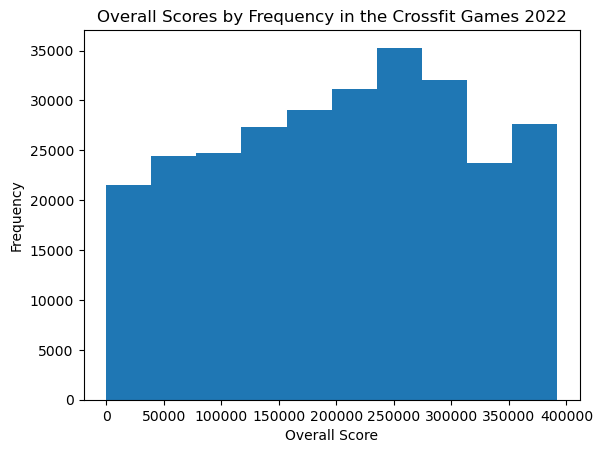

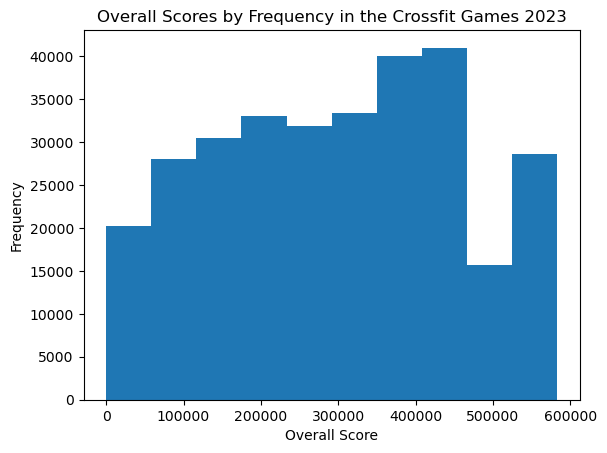

```python
# Note "overallScore" is the final score each candidate achieved
# Hint: Before you write the loop, test your code out by opening an individual dataset
# Once you're sure the code works and you're familiar with the data, run the loop
dfopen22 = pd.read_csv("data\df_open_2022.csv")
dfopen23 = pd.read_csv("data\df_open_2023.csv")
dfopen = [dfopen22,dfopen23]
name = ['2022','2023']
for i in range(0,2):
    plt.hist(dfopen[i]["overallScore"])
    plt.title('Overall Scores by Frequency in the Crossfit Games ' + str(name[i]))
    plt.xlabel('Overall Score')
    plt.ylabel('Frequency')
    plt.show()
```

For questions (d) and (e), use the following table:

[figure not shown]

(d) Loops with multiple lists

- Create three lists

list_lower = [93, 90, 87, 83, 80, 77, 73, 70, 67, 63, 60, 0]

list_upper = [100, 92, 89, 86, 82, 79, 76, 72, 69, 66, 62, 59]

list_letters = ["A","A-","B+","B","B-","C+","C","C-","D+","D","D-","F"]

- Create a for loop that prints the message:

"If a students gets a grade between .... and ..., their letter grade is ..."

```python
# Hint: Use a for-loop with numbering
# Start the index at zero
# In the body of the loop, extract the elements in each list by the index position
list_lower = [93,90,87,83,80,77,73,70,67,63,60,0]
list_upper = [100,92,89,86,82,79,76,72,69,66,62,59]
list_letters = ["A","A-","B+","B","B-","C+","C","C-","D+","D","D-","F"]
for i in range(0,len(list_letters)):
    print('If a student gets a grade between '+ str(list_lower[i]) + ' and ' + str(list_upper[i]) + ', their letter grade is '+ str(list_letters[i]) + '.')
```

```
If a student gets a grade between 93 and 100, their letter grade is A.
If a student gets a grade between 90 and 92, their letter grade is A-.
If a student gets a grade between 87 and 89, their letter grade is B+.
If a student gets a grade between 83 and 86, their letter grade is B.
If a student gets a grade between 80 and 82, their letter grade is B-.
If a student gets a grade between 77 and 79, their letter grade is C+.
If a student gets a grade between 73 and 76, their letter grade is C.
If a student gets a grade between 70 and 72, their letter grade is C-.
If a student gets a grade between 67 and 69, their letter grade is D+.
If a student gets a grade between 63 and 66, their letter grade is D.
If a student gets a grade between 60 and 62, their letter grade is D-.
If a student gets a grade between 0 and 59, their letter grade is F.
```

(e) Classification with double loops

- Suppose that 7 students get the following grades:

list_studentgrades = [84, 62, 92, 74, 97, 80, 79]

- Print the following message:

"The student got a numeric grade of .... and their letter grade was ..."

```python
#(a) Hint: Use a double for loop structure:
#---- for studentgrade in list_studentgrades:
#----     index = 0
#----     for letter in list_letters:
#----          Body
#----          index = index + 1

# (b) Inside the body, use an if/else statement to print the correct letter grade.
# You can make your code more concise by doing similar steps to question (d).

list_studentgrades = [84,62,92,74,97,80,79]
for studentgrade in list_studentgrades:
    index = 0
    for letter in list_letters:
        if studentgrade >= list_lower[index] and studentgrade <= list_upper[index]:
            print("The student got a numeric grade of " + str(studentgrade) + 'and their letter grade was ' + str(list_letters[index]))
        index = index + 1
```

```
The student got a numeric grade of 84and their letter grade was B
The student got a numeric grade of 62and their letter grade was D-
The student got a numeric grade of 92and their letter grade was A-
The student got a numeric grade of 74and their letter grade was C
The student got a numeric grade of 97and their letter grade was A
The student got a numeric grade of 80and their letter grade was B-
The student got a numeric grade of 79and their letter grade was C+
```